# Assignment3_IT_Helpdesk_Modeling

Minghao Du

# Set-up

Load packages.

```r
rm(list = ls())
library(readxl)
library(tidyverse)
library(ggplot2)
```

For this and the next assignments (Assignment 3 and 4), you will use the dataset from https://www.ibm.com/communities/analytics/watson-analytics-blog/it-help-desk/. (the link is now invalid.) This data is from an Information Technology (IT) department interested in improving the satisfaction of customers.  
To start their analysis, they constructed this data set of 100,000 closed tickets that were filed at their help desk.

Load the dataset and save it as ithelp.

```r
ithelp <- read_excel("WA_Fn-UseC_-IT-Help-Desk.xlsx")
```

```r
glimpse(ithelp)
```

```
Rows: 100,000
Columns: 10
$ ticket             <dbl> 1, 2, 3, 4, 5, 6, 7, 8, 9, 10, 11, 12, 13, 14, 15, 16, 17, 18~
$ Requestor          <dbl> 1929, 1587, 925, 413, 318, 858, 1978, 1209, 887, 1780, 1349, ~
$ RequestorSeniority <chr> "1 - Junior", "2 - Regular", "2 - Regular", "4 - Management",~
$ ITOwner            <dbl> 50, 15, 15, 22, 22, 38, 10, 1, 14, 46, 1, 50, 11, 26, 9, 7, 2~
$ FiledAgainst       <chr> "Systems", "Software", "Access/Login", "Systems", "Access/Log~
$ TicketType         <chr> "Issue", "Request", "Request", "Request", "Request", "Request~
$ Severity           <chr> "2 - Normal", "1 - Minor", "2 - Normal", "2 - Normal", "2 - N~
$ Priority           <chr> "0 - Unassigned", "1 - Low", "0 - Unassigned", "0 - Unassigne~
$ daysOpen           <dbl> 3, 5, 0, 20, 1, 0, 9, 15, 6, 1, 7, 17, 10, 4, 7, 11, 0, 7, 7,~
$ Satisfaction       <chr> "1 - Unsatisfied", "1 - Unsatisfied", "0 - Unknown", "0 - Unk~
```

A total of 100,000 rows. Each row represent an individual request. The data includes:

- Requestor: employee who submitted the ticket
- RequestorSeniority: employee’s seniority within the company
- ITOwner: IT employee who serviced the ticket
- FileAgainst: functional area against which the ticket was filed (systems, software, hardware, access)
- TicketType: whether the ticket was a request for new services or an issue with existing services
- Severity: submitter-assigned severity of the ticket
- Priority: IT-assigned priority of the ticket
- daysOpen: number of days the ticket was open
- Satisfaction: satisfaction with the resolution of the ticket (reported by the submitter)

```r
summary(ithelp)
```

```
     ticket         Requestor    RequestorSeniority    ITOwner      FiledAgainst
 Min.   :     1   Min.   :   1   Length:100000      Min.   : 1.00   Length:100000
 1st Qu.: 25001   1st Qu.: 499   Class :character   1st Qu.:13.00   Class :character
 Median : 50001   Median : 999   Mode  :character   Median :26.00   Mode  :character
 Mean   : 50001   Mean   : 999                      Mean   :25.46
 3rd Qu.: 75000   3rd Qu.:1499                      3rd Qu.:38.00
 Max.   :100000   Max.   :2000                      Max.   :50.00
  TicketType          Severity           Priority            daysOpen
 Length:100000      Length:100000      Length:100000      Min.   : 0.000
 Class :character   Class :character   Class :character   1st Qu.: 1.000
 Mode  :character   Mode  :character   Mode  :character   Median : 5.000
                                                          Mean   : 6.843
                                                          3rd Qu.:10.000
                                                          Max.   :54.000
 Satisfaction
 Length:100000
 Class :character
 Mode  :character
```

Some ‘character’ variables behave unexpectedly. Let’s convert all character variables into factors, which indicate categorical variables in R.

```r
ithelp<-ithelp%>%
  mutate(ticket=as.factor(ticket),
         Requestor=as.factor(Requestor),
         RequestorSeniority=as.factor(RequestorSeniority),
         ITOwner=as.factor(ITOwner),
         FiledAgainst=as.factor(FiledAgainst),
         TicketType=as.factor(TicketType),
         Severity=as.factor(Severity),
         Priority=as.factor(Priority),
         Satisfaction=as.factor(Satisfaction))
```

Let’s check the summary again.

```r
summary(ithelp)
```

```
     ticket        Requestor          RequestorSeniority    ITOwner
 1      :    1   285    :   74   1 - Junior    :20040    3      : 2084
 2      :    1   754    :   74   2 - Regular   :41303    39     : 2080
 3      :    1   79     :   73   3 - Senior    :18801    48     : 2072
 4      :    1   636    :   72   4 - Management:19856    35     : 2058
 5      :    1   1341   :   72                           24     : 2045
 6      :    1   523    :   70                           4      : 2040
 (Other):99994   (Other):99565                           (Other):87621
       FiledAgainst     TicketType                Severity               Priority
 Access/Login:29921   Issue  :24926   0 - Unclassified:  367   0 - Unassigned:30127
 Hardware    : 9976   Request:75074   1 - Minor       : 2317   1 - Low       :17117
 Software    :20068                   2 - Normal      :90912   2 - Medium    :16258
 Systems     :40035                   3 - Major       : 4974   3 - High      :36498
                                      4 - Critical    : 1430


    daysOpen                    Satisfaction
 Min.   : 0.000   0 - Unknown         :30211
 1st Qu.: 1.000   1 - Unsatisfied     :21124
 Median : 5.000   2 - Satisfied       :19602
 Mean   : 6.843   3 - Highly satisfied:29063
 3rd Qu.:10.000
 Max.   :54.000
```

It turns out that there are many cases with “Unknown” Satisfaction. Let’s exclude these cases from the analysis (Step 1: filter). Next, we may build a multi-class classification model (Unsatisfied, Satisfied, Highly satisfied), but let’s simplify it to a binary classifier and identify “Unsatisfied” cases, which are problematic. Create a new variable, “negative”, which indicates if a user’s feedback is negative (Step 2: mutate). The following code will do these jobs for you.

```r
ithelp<-ithelp%>%
  filter(Satisfaction!="0 - Unknown")%>%
  mutate(negative=as.factor(ifelse(Satisfaction =="1 - Unsatisfied","Yes","No")))

summary(ithelp)
```

```
     ticket        Requestor          RequestorSeniority    ITOwner
 1      :    1   442    :   56   1 - Junior    :13995    39     : 1470
 2      :    1   1489   :   55   2 - Regular   :28963    24     : 1442
 5      :    1   98     :   53   3 - Senior    :13027    19     : 1440
 9      :    1   248    :   53   4 - Management:13804    3      : 1437
 10     :    1   1391   :   53                           48     : 1437
 12     :    1   1498   :   53                           31     : 1435
 (Other):69783   (Other):69466                           (Other):61128
       FiledAgainst     TicketType                Severity               Priority
 Access/Login:20990   Issue  :17454   0 - Unclassified:  263   0 - Unassigned:20984
 Hardware    : 6912   Request:52335   1 - Minor       : 1620   1 - Low       :12045
 Software    :13972                   2 - Normal      :63459   2 - Medium    :11409
 Systems     :27915                   3 - Major       : 3445   3 - High      :25351
                                      4 - Critical    : 1002


    daysOpen                   Satisfaction   negative
 Min.   : 0.00   0 - Unknown         :    0   No :48665
 1st Qu.: 1.00   1 - Unsatisfied     :21124   Yes:21124
 Median : 5.00   2 - Satisfied       :19602
 Mean   : 6.83   3 - Highly satisfied:29063
 3rd Qu.:10.00
 Max.   :49.00
```

# Q1. Classification tree model

```r
library(rpart)
library(rpart.plot)
```

Build a model to predict “negative” with the following variables. Fill in the blank to complete the code below. * RequestorSeniority * FiledAgainst * TicketType * Severity * Priority * daysOpen

Set the control as `control=rpart.control(cp=0.001)`.

```r
ct_model<-rpart(negative ~ RequestorSeniority+FiledAgainst+TicketType+Severity+Priority+daysOpen,    # model formula
                data = ithelp,             # dataset
                method="class",            # "class" indicates a classification tree model
                control=rpart.control(cp=0.001))   # tree control parameters.
```

Display the tree model with `rpart.plot` and answer the following questions based on this model result.

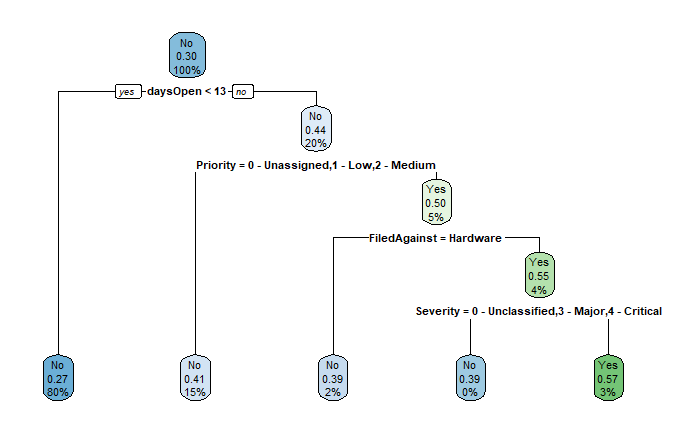

Question 1: Which one of the following characterizes the case that receive negative feedback (i.e. the probability of negative feedback greater than 50%)?

1. Not closed (i.e. resolved) within 12 days (daysOpen=>13 days)
2. Priority is High
3. Not filed against Hardware (i.e. filed against Access/Login, Software, or Systems)
4. Severity is either minor or normal
5. All conditions above should be met.

Question 2: What is the probability that a case receives negative feedback if the case is resolved within 12 days? (1) 27% (2) 41% (3) 80% (4) Cannot know.

# Logit Regression Model

Build a logit regression model to predict “negative” with the following variables. Fill in the blank to complete the code below. * RequestorSeniority * FiledAgainst * TicketType * Severity * Priority * daysOpen

```r
logit_model<-glm(negative ~ RequestorSeniority+FiledAgainst+TicketType+Severity+Priority+daysOpen,
                 family="binomial",
                 data = ithelp)
summary(logit_model)
```

```
Call:
glm(formula = negative ~ RequestorSeniority + FiledAgainst +
    TicketType + Severity + Priority + daysOpen, family = "binomial",
    data = ithelp)

Deviance Residuals:
    Min       1Q   Median       3Q      Max
-1.8326  -0.8304  -0.7416   1.3127   2.1834

Coefficients:
                                  Estimate Std. Error z value Pr(>|z|)
(Intercept)                      -0.165590   0.131668  -1.258 0.208524
RequestorSeniority2 - Regular     0.014075   0.023388   0.602 0.547322
RequestorSeniority3 - Senior     -0.060720   0.029196  -2.080 0.037552 *
RequestorSeniority4 - Management -0.020905   0.029468  -0.709 0.478064
FiledAgainstHardware             -1.544872   0.045352 -34.064  < 2e-16 ***
FiledAgainstSoftware             -0.494240   0.026275 -18.811  < 2e-16 ***
FiledAgainstSystems              -0.778581   0.026288 -29.618  < 2e-16 ***
TicketTypeRequest                -0.399541   0.020834 -19.177  < 2e-16 ***
Severity1 - Minor                 0.163199   0.138826   1.176 0.239769
Severity2 - Normal               -0.397980   0.129497  -3.073 0.002117 **
Severity3 - Major                -0.997003   0.135929  -7.335 2.22e-13 ***
Severity4 - Critical             -0.974058   0.150456  -6.474 9.54e-11 ***
Priority1 - Low                  -0.097741   0.026535  -3.683 0.000230 ***
Priority2 - Medium                0.041825   0.025866   1.617 0.105890
Priority3 - High                  0.075306   0.021471   3.507 0.000453 ***
daysOpen                          0.084106   0.001716  49.027  < 2e-16 ***
---
Signif. codes:  0 ‘***’ 0.001 ‘**’ 0.01 ‘*’ 0.05 ‘.’ 0.1 ‘ ’ 1

(Dispersion parameter for binomial family taken to be 1)

    Null deviance: 85578  on 69788  degrees of freedom
Residual deviance: 82753  on 69773  degrees of freedom
AIC: 82785

Number of Fisher Scoring iterations: 4
```

Question 3: Which of the following is NOT an implication that you can draw from this logit regression result?

1. An increase in the daysOpen is associated with a higher chance of negative feedback.
2. A request with high priority is more likely to receive negative feedback.
3. Compared to Junior, a request from Senior is more likely to receive negative feedback.
4. All of the above

Question 4. Save the predicted probability from a logit model by creating a new variable *logit_pred* in the dataset. What is the probability that the ticket number 1404 receives negative feedback?

```r
ithelp$logit_pred<-predict(logit_model, type = "response")
ithelp%>%
  filter(ticket == 1404)
```

| ticket | Requestor | RequestorSeniority | ITOwner | FiledAgainst | TicketType | Severity | Priority | daysOpen | Satisfaction | negative | logit_pred |
| --- | --- | --- | --- | --- | --- | --- | --- | --- | --- | --- | --- |
| 1404 | 857 | 2 - Regular | 38 | Systems | Request | 2 - Normal | 2 - Medium | 6 | 2 - Satisfied | No | 0.2348444 |

1. 18%
2. 23%
3. 53%
4. 118%

Question 5. The same as the previous assignments, your last task is creating a report. Change the author name on the top of this R markdown file to yours. Compile this R markdown file into a Word or html document and submit it through the course Blackboard. Your report should contain all codes and results of in-class exercises as well as the assignment questions and answers.